# Data Aquisition Blog: Observation of Data Science and ML Positions

Required Technical Skills of Current Open Positions and Their Respective Salaries

Author

Connor Gordon

Published

November 6, 2026

## Which technical skills are connected with senior level data positions?

As a “Statistics: Data Science” student at BYU, I want to connect the tools I learn with possible career paths. Browsing many openings from one large company gives a bit of a narrow impression of skills I need to have to apply. This prompted me to ask myself: which technical skills appear in senior AI, machine learning, data science, and analytics roles across most employers, and is their a connection between these skills and higher paying positions? This blog will explore the salaries and necessary skills of Data Scientists, Machine Learning/AI Engineers, and other data-related roles.

## Data Overview and API Details

I used the [public Greenhouse Job Board API](https://docs.greenhouse.io/job-board.html) to collect job descriptions. Greenhouse documents that the public GET endpoints require no API key and lists no request quota in the Job Board API documentation. A [LastRound AI directory](https://github.com/fyrosofttech/lastroundai-hiring-data/tree/main/ats-directory) supplied 4,966 candidate Greenhouse boards across the alphabet - its directory is licensed, and credit also goes to the directory’s [salary-transparency study](https://lastroundai.com/blog/salary-transparency-study-2026). I got the historical live job board counts from this open-ats-feed. The most historically active job boards were visited first.

## Breadth of Data Aquisition

The data consists of over 300 job descriptions with over 100 different companies represented in the dataset. I only allowed five samples from each company (including failures and descriptions without pay) as to not inflate the data pool with one company and their requirements.

I first requested its title list without description content to make the search faster, then I removed repeated internal role IDs and selected across role families before adding more from a family, checking for employerIDs and saved IDs as to prevent restarts from replacing unsuccessful selections. After review of my web scraping I found that there were some overlapping roles in companies such as xai, wpp, fanaticscollectibles, and vmlenterprisesolutions. I decided to exclude those later job boards entirely, preserved their requests in the audit history, and blocked future requests there to keep the final sample count below five.

This excerpt shows the basic function for obtaining the json object of the job boards:

```python
# These IDs were selected and saved before requesting details.
for job_id in cache["planned_ids"]:
    detail_url = (
        f"https://boards-api.greenhouse.io/v1/boards/{board}/jobs/{job_id}"
        "?pay_transparency=true"
    )
    detail = get_json(session, detail_url)
```

The complete workflow is in `project.py` and is much more complex. I wanted to search for senior positions for the sake of avoiding bias, so I searched for key phrases Senior/Sr., Staff, Principal, Lead, Distinguished, or relevant management/leadership wording while explicitly rejecting internship and junior positions. Research-scientist titles also need machine-learning or data-science evidence in their descriptions.

The search inspected 278 boards containing 87,943 metadata entries, and attempted 617 descriptions. Metadata entries are not collected descriptions. Cleaning found 303 qualifying salary-disclosing roles across 102 companies. I retained one role per contributing company first, then filled the count of job listings to 300 with 53 variables and a maximum of 5 roles per company.

## Related careers have different tools

| Role family | Retained roles |
| --- | --- |
| Machine learning / AI | 113 |
| Data engineering | 57 |
| Data / business analytics | 54 |
| Data science | 50 |
| Applied / quantitative science | 14 |
| Analytics engineering / BI | 12 |

The related families include data engineering, analytics engineering/BI, business analytics, and applied or quantitative science. Common exact titles include Senior Data Scientist (6 roles, 6 employers); Staff Data Scientist (5 roles, 5 employers); Senior Data Engineer (4 roles, 4 employers).

After decoding HTML, I used explicit text patterns for 13 skills. The blue bars show the percentage of individual postings that mention each skill, counting every posting equally. For the gold bars, I calculate the percentage within each company first, then average those percentages so every company counts equally. A company with five postings has five times the weight of a company with one in the blue bars and the same weight in the gold bars.

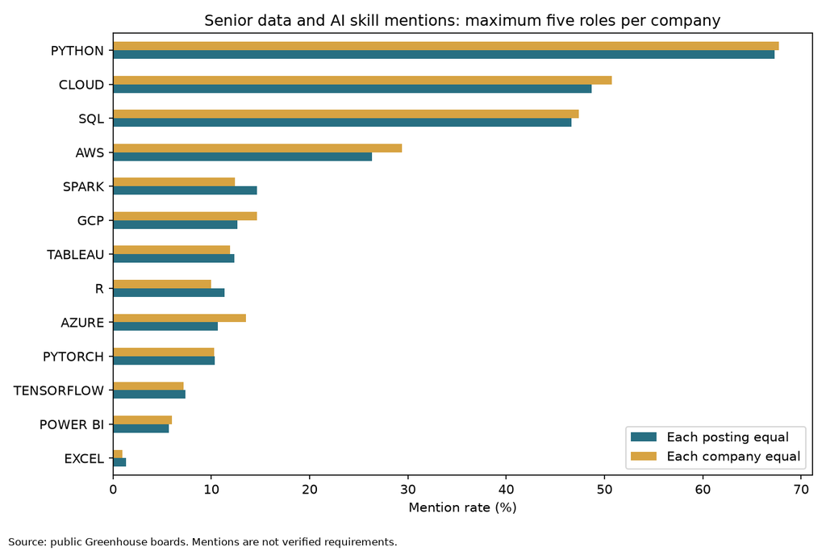

Skill mention rates with equal weight per posting and equal weight per company.

The most popular technical skills seem to be Python, then cloud computing skills, then SQL. A posting counts toward “cloud” if it mentions AWS, Azure, GCP, or the word “cloud.” Averaging within each company and then across companies gives Python 67.7%, SQL 47.4%, and cloud 50.7%.

## Analysis of Pay Scale by Role

The salary comparison uses 145 postings from 51 employers. Employers supplied the dollar bounds in each posting. The only inference was whether the pay period was annual, using information from that same posting. For 35 postings the annual period was explicit. For the other 110, I treated an unspecified period as annual if the posting specified USD, listed a recognizable U.S. location, had both bounds between $25,000 and $1,000,000, and contained no conflicting pay-period wording. The bounds screen for plausible annual ranges and can favor higher ranges by excluding amounts below the cutoff.

When a posting lists several qualifying regional ranges, I use the lowest lower bound and highest upper bound. The published $17,100–$253,000 range is included as reported because the annual period was explicit.

For each posting, I model the advertised range with a normal curve centered on its midpoint. A $100,000–$150,000 range gives a midpoint of $125,000 and a standard deviation of $12,500, one-quarter of the range width. The teal curves average these models with equal weight per posting, and the orange dashed lines show the mean of the posting midpoints. These curves illustrate advertised pay under the annual-period assumption. The model can extend past the posted bounds.

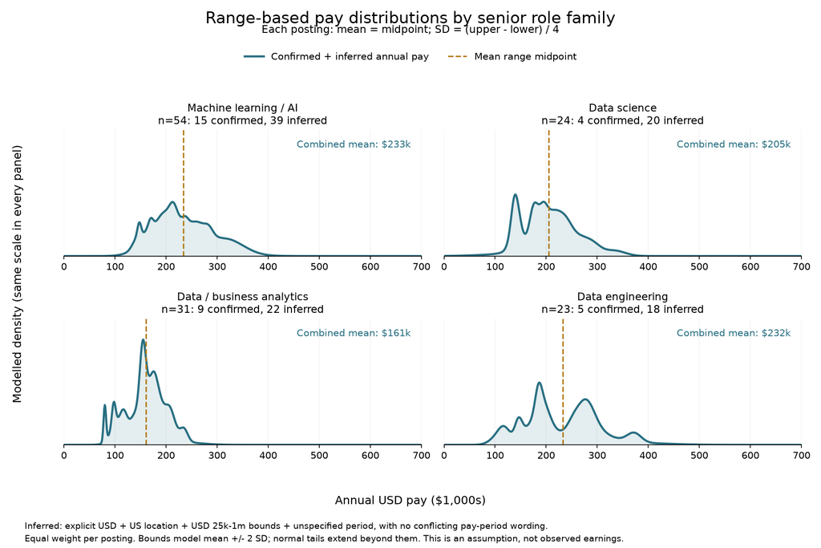

Modeled distributions of advertised annual USD pay for role families with at least 10 comparable postings.

I used a minimum of 10 comparable postings to show a curve. Analytics engineering / BI and applied / quantitative science have 7 and 6 comparable postings, respectively, so their counts and averages appear only in the table.

| Role family | Comparable postings | Mean advertised midpoint, rounded |
| --- | --- | --- |
| Machine learning / AI | 54 | $233,000 |
| Data science | 24 | $205,000 |
| Data / business analytics | 31 | $161,000 |
| Data engineering | 23 | $232,000 |
| Analytics engineering / BI | 7 | $174,000 |
| Applied / quantitative science | 6 | $235,000 |

Among the four plotted families, mean midpoints range from about $161,000 for data/business analytics to $233,000 for AI/ML. Location, employer mix, and seniority may contribute to these differences. I did not adjust for those factors.

## Limits and Conclusion

Some limits and bias may be caused by using greenhouse as a source for data - coverage, historical board activity, salary disclosure, title rules, and the five-role cap from greenhouse all shape this sample. Even though we weighted it equally by company, there’s only so much we can do in order to avoid potential biases, and this analysis only officially applies to the data I collected and not the general population of data roles.

I used public, read-only requests and avoided applicant data and private endpoints. The script sends one request at a time, pauses for three seconds after each response, and uses a 30-second timeout and a local cache. An HTTP 429 response (Too Many Requests) or an access block stops the run without an automatic retry.

For my own career planning, Python, cloud tools, and SQL are good places to focus because they came up often in these postings. The advertised ranges also give me a starting point for comparing senior roles. In this sample, machine learning / AI, data engineering, and data science had higher average advertised midpoints than data / business analytics.

The Python code and instructions are available in the [Data Acquisition project repository](https://github.com/Nacho9771/Data_Aquisition_Lab).